# Basic Reinforcement Learning

```
Author:
Zach Wolpe
zachcolinwolpe@gmail.com
www.zachwolpe.com
```

## Intuition

Reinforcement learning - also called online learning - is used to solve interactive problems where data is obtained up to time $t$ & used to decide which action to take at time $t+1$.

The agent learns through trail & error wherein *REWARDS* are distributed for favourable actions & *PUNISHMENTS* are implemented for unfavourable actions.

Essentially taking the following structure:

```
- Describe the possibilities: inform the agent of what is it capable of doing (what actions are possible to take)
- Set up a reward/punishment structure
- Allow the agent to explore the game space through trail & error 'learning' effective methods
```

More complecated models, particularly in robotics & game solving, account for the sparse reward problem as well as model curiosity.

## Multi-Arm Bandit Problem

A 1-arm bandit refers to a traditional slot machine with a (pull) lever - bandit as in it takes all your money. The multi-arm bandit problem refers to a situation where there are multiple slot machines & we want to calculate the best way to play the machines (order, frequency etc) to maximize expected returns. Each machine has a different win/loss ratio & thus a different distribution of possible successes. By implementing online learning it is possible to find the machine with the highest probability of success quickly, by updating our beliefs every iteration.

Pragmatically, this approach can be used to test multiple ad-campaigns to find the most successful ad in the optimal time period - without running large expensive test.

## Further Notes:

We can use confidence bounds to approximate 'regret' when considering exploration vs exploitation tradeoffs. Insufficient exploration means we may be stuck at a local maximum, but excessive exploration means not capitalizing on what we know (exploitation) to be true & incurring more risk.

## Models

Two models are covered in this tutorial:

```
- Upper Confidence Bound (UCB)
- Thompson Sampling
```

# Upper Confidenc Bound (UCB)

Suppose we have 5 different ads to run, one options is to do an A-B test and run all five for a short period & thereafter assess the results to see which ads caused the most clicks. This can be considered as performing exploration (trying different ads) & exploitation (using the best ad to maximise revenue) seperately - & may be a sub-optimal approach.

## Algorithm

Suppose there are *d* ads to test, when an add is displayed to a user the user can either click the ad or not click the ad (recorded as $\in [0,1]$). Initially we cannot distinguish between the ads' performance so we set all the expected values of each ad to $E[d_i]=0.5$ with extremely wide confidence bounds to include the majority of the $\in [0,1]$ range. Thereafter:

```
- Run a trail run where each ad is run once
- Use the data to update the confidence bounds per trail
- More trails (data) -> smaller confidence bounds -> long run convergence to the true Expected value
- Therafter select the option with the highest Upper Confidence Limit (UCB)
- The most favourable ad (highest expected return) should then repeatedly be selected. Each select reduces the confidence bounds & there should be periods when other ads have hight UCBs - ensuring sufficient exploration.
- Eventually (relatively quickly) the ad with the highest expected value will only be chosen.
```

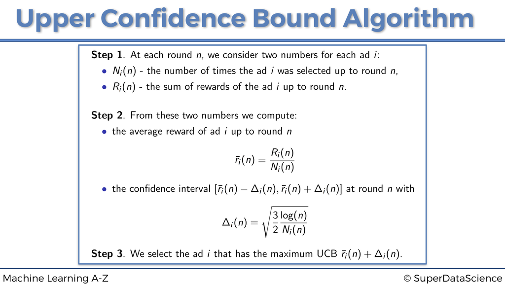

```python
from IPython.display import Image
Image(filename='UCB_Algorithm_Slide.png')
```

```python
# Importing the libraries
import numpy as np
import matplotlib.pyplot as plt
import pandas as pd

%matplotlib inline
plt.style.use('ggplot')
```

[output not shown]

## Dataset

The data contains the Click Though Rate of each ad (1 if clicked, 0 if not).

We have a dataset to assess the algorithm, however this unsupervised technique requires no data, but there updates (online or interative learning) per iteration.

The goal is to maximise *total reward*.

```python
# Importing the dataset
dataset = pd.read_csv('Ads_CTR_Optimisation.csv')
print('shape: ', dataset.shape)
dataset.head()
```

```
shape:  (10000, 10)
```

|  | Ad 1 | Ad 2 | Ad 3 | Ad 4 | Ad 5 | Ad 6 | Ad 7 | Ad 8 | Ad 9 | Ad 10 |
| --- | --- | --- | --- | --- | --- | --- | --- | --- | --- | --- |
| 0 | 1 | 0 | 0 | 0 | 1 | 0 | 0 | 0 | 1 | 0 |
| 1 | 0 | 0 | 0 | 0 | 0 | 0 | 0 | 0 | 1 | 0 |
| 2 | 0 | 0 | 0 | 0 | 0 | 0 | 0 | 0 | 0 | 0 |
| 3 | 0 | 1 | 0 | 0 | 0 | 0 | 0 | 1 | 0 | 0 |
| 4 | 0 | 0 | 0 | 0 | 0 | 0 | 0 | 0 | 0 | 0 |

## Random Selection

To show that the results of the UCB are significantly better than random selection, here is a random selection algorthm that performs the same function. It is appearent that each group is selected with equal probabilities.

```
total reward (clicks):  1244
```

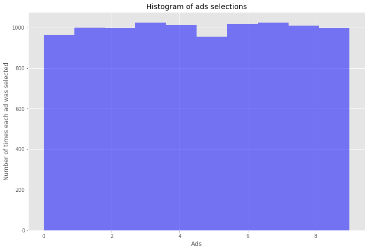

```python
# Implementing Random Selection
import random
N = 10000
d = 10
ads_selected = []
total_reward = 0
for n in range(0, N):
    ad = random.randrange(d)
    ads_selected.append(ad)
    reward = dataset.values[n, ad]
    total_reward = total_reward + reward

print('total reward (clicks): ', total_reward)

# Visualising the results
plt.figure(figsize=(12,8))
plt.hist(ads_selected, alpha=0.5, color='b')
plt.title('Histogram of ads selections')
plt.xlabel('Ads')
plt.ylabel('Number of times each ad was selected')
plt.show()
```

## UCB

Note how the optimal add was chosen for more often, resulting in almost double *total reward*. Inspecting the _ads*selected* variable indicates the sequence of ads selected.

```
total reward (clicks):  2178
```

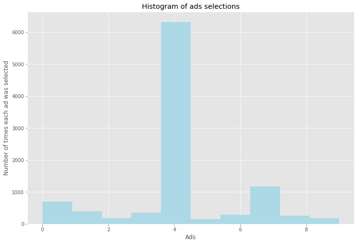

```python
# Implementing UCB
import math
N = 10000
d = 10
ads_selected = []
numbers_of_selections = [0] * d
sums_of_rewards = [0] * d
total_reward = 0
for n in range(0, N):
    ad = 0
    max_upper_bound = 0
    for i in range(0, d):
        if (numbers_of_selections[i] > 0):
            average_reward = sums_of_rewards[i] / numbers_of_selections[i]               # expected value
            delta_i = math.sqrt(3/2 * math.log(n + 1) / numbers_of_selections[i])        # delta in formula
            upper_bound = average_reward + delta_i                                       # upper confidence bound
        else:
            upper_bound = 1e400                                                          # 10^400
        if upper_bound > max_upper_bound:
            max_upper_bound = upper_bound
            ad = i
    ads_selected.append(ad)
    numbers_of_selections[ad] = numbers_of_selections[ad] + 1
    reward = dataset.values[n, ad]
    sums_of_rewards[ad] = sums_of_rewards[ad] + reward
    total_reward = total_reward + reward



print('total reward (clicks): ', total_reward)

# Visualising the results
plt.figure(figsize=(12,8))
plt.hist(ads_selected, color='lightblue')
plt.title('Histogram of ads selections')
plt.xlabel('Ads')
plt.ylabel('Number of times each ad was selected')
plt.show()
```

# Thompson Sampling

Thompson Sampling addesses the same situational problem, & employs a Bayesian updating to model the best possible choice. Thompsom Sampling is a probabilistic model (as apposed to the deterministic UCB) - accounting for sampling variation.

This sampling technique essentially creates a bayesian model of the expected returns on each ad, updating priors per iteration, swiftly learning accurate posteriors.

Utilizing the same dataset:

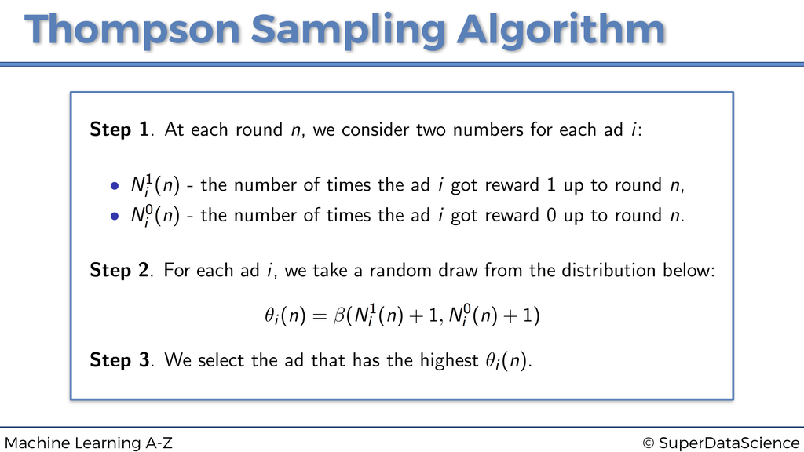

```python
from IPython.display import Image
Image(filename='Thompson_Sampling_Slide.png')
```

```
total reward (clicks):  2609
```

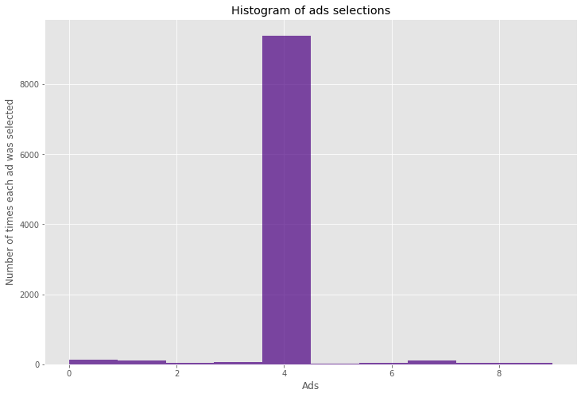

```python
# Thompson Sampling

# Implementing Thompson Sampling
import random
N = 10000
d = 10
ads_selected = []
numbers_of_rewards_1 = [0] * d
numbers_of_rewards_0 = [0] * d
total_reward = 0
for n in range(0, N):
    ad = 0
    max_random = 0
    for i in range(0, d):
        random_beta = random.betavariate(numbers_of_rewards_1[i] + 1, numbers_of_rewards_0[i] + 1)
        if random_beta > max_random:
            max_random = random_beta
            ad = i
    ads_selected.append(ad)
    reward = dataset.values[n, ad]
    if reward == 1:
        numbers_of_rewards_1[ad] = numbers_of_rewards_1[ad] + 1
    else:
        numbers_of_rewards_0[ad] = numbers_of_rewards_0[ad] + 1
    total_reward = total_reward + reward


print('total reward (clicks): ', total_reward)

# Visualising the results - Histogram
plt.figure(figsize=(12,8))
plt.hist(ads_selected, color='indigo', alpha=0.7)
plt.title('Histogram of ads selections')
plt.xlabel('Ads')
plt.ylabel('Number of times each ad was selected')
plt.show()
```

# Comparison

A brief summary to compare the two approaches:

## UCB

- Deterministic algorithm
- Requires immediate feedback for updating
- Thus computationally expensive (constant updating)

## Thompson Sampling

- Probabilistic algorithm (incorporates distributions)
- Does not requires immediate feedback for Bayesian updating
- Computationally inexpensive as updating can be done in batches
- Better empirical evidence